# 3.5 - Notas de Luis - Regresión logística desde cero

Cuatro meses después del proyecto de predicción de suministros, el Hospital Minermont se enfrenta a una nueva pregunta: **¿acudirá un paciente a su cita?** En el conjunto del hospital se pierde alrededor del 18% de las citas, y en algunas especialidades hasta el 27%. Fisioterapia tiene la tasa más alta, así que el piloto empieza allí.

Esta vez no predecimos una cantidad, como las mascarillas del capítulo 2, sino una respuesta de sí o no: un problema de **clasificación binaria**. La regresión logística conserva la puntuación lineal de la regresión lineal, $z = w \cdot x + b$, y la pasa por la función **sigmoide**, que convierte cualquier número en una probabilidad entre 0 y 1:

$$\hat{p} = \sigma(z) = \frac{1}{1 + e^{-z}}$$

Si $\hat{p}$ supera un **umbral** (normalmente 0,5), predecimos que el paciente no acudirá.

En este cuaderno la construimos desde cero con NumPy, igual que hicimos con la regresión lineal:

1. Importar las bibliotecas.
2. Crear un conjunto de datos sintético de citas de Fisioterapia.
3. Preparar los datos: conjuntos de entrenamiento y prueba, y escalado de características.
4. Definir la función sigmoide.
5. Definir la función de coste (entropía cruzada, o *log loss*).
6. Entrenar el modelo con descenso del gradiente.
7. Evaluarlo: matriz de confusión, sensibilidad, especificidad, VPP y VPN.
8. Elegir el umbral de decisión.
9. Interpretar los coeficientes.
10. Predecir para pacientes nuevos.

### Paso 1: Importar las bibliotecas

`numpy` para los cálculos, `pandas` para manejar los datos como una tabla y `matplotlib` para las gráficas. De scikit-learn solo usaremos una utilidad: dividir los datos en entrenamiento y prueba. El modelo lo escribimos nosotros.

```python
import numpy as np
import pandas as pd
import matplotlib.pyplot as plt
from sklearn.model_selection import train_test_split  # solo para dividir los datos

np.set_printoptions(precision=3, suppress=True)
print("Bibliotecas cargadas.")
```

```
Bibliotecas cargadas.
```

### Paso 2: Un conjunto de datos sintético de citas

Mientras Marta y Víctor reúnen los registros reales de asistencia del hospital, yo estoy creando un conjunto de datos sintético, como hicimos en el capítulo 2. Cada fila es una cita de Fisioterapia, descrita por las variables que el equipo consideró relevantes:

| Columna | Significado |
| --- | --- |
| `edad` | Edad del paciente (18–85 años) |
| `dias_desde_ultima_cita` | Días desde la cita anterior del paciente |
| `distancia_km` | Distancia de casa al hospital, en km (Minermont atiende una zona rural) |
| `hora` | Hora de la cita (de 8 a 19 h) |
| `primera_visita` | 1 si es una primera visita, 0 si es una revisión |
| `ausencias_previas` | Número de citas a las que el paciente faltó anteriormente |
| `no_asiste` | **Objetivo**: 1 si el paciente **no** acudió, 0 si acudió |

La **clase positiva** (1) es la ausencia, porque es el suceso que queremos detectar. Detrás de los datos hay una regla oculta que solo usamos para generar las citas; el modelo tendrá que descubrir el patrón a partir de los ejemplos.

```python
def generate_appointments(n, seed):
    """Citas sintéticas de Fisioterapia en Minermont: una fila por cita."""
    rng = np.random.default_rng(seed)
    age = rng.integers(18, 86, n)                                  # años
    days = rng.integers(1, 181, n)                                 # días desde la cita anterior
    distance = np.round(rng.gamma(2.0, 6.0, n).clip(0.5, 60), 1)   # km hasta el hospital (zona rural)
    hour = rng.integers(8, 20, n)                                  # hora de la cita, de 8:00 a 19:00
    first = rng.binomial(1, 0.35, n)                               # 1 = primera visita, 0 = revisión
    previous = rng.poisson(0.6, n).clip(0, 6)                      # ausencias en el historial del paciente
    late = np.where(hour >= 17, hour - 16, 0)                      # a última hora de la tarde se falta más

    # La regla oculta detrás de los datos. Solo la usamos para generar las citas:
    # el modelo nunca la ve y tiene que descubrir el patrón a partir de los ejemplos.
    z = (-1.55 - 0.069 * (age - 50) + 0.026 * (days - 90) + 0.11 * (distance - 12)
         + 1.5 * (previous - 0.6) + 0.56 * (late - 0.75) + 0.63 * (first - 0.35))
    no_show = rng.binomial(1, 1 / (1 + np.exp(-z)))                # 1 = no acudió

    return pd.DataFrame({
        'edad': age, 'dias_desde_ultima_cita': days, 'distancia_km': distance, 'hora': hour,
        'primera_visita': first, 'ausencias_previas': previous, 'no_asiste': no_show,
    })
```

```python
df = generate_appointments(1200, seed=42)

print(f"Citas: {len(df)}")
print(f"Tasa de ausencias: {df['no_asiste'].mean():.1%}")
df.head()
```

```
Citas: 1200
Tasa de ausencias: 26.2%
```

|  | edad | dias_desde_ultima_cita | distancia_km | hora | primera_visita | ausencias_previas | no_asiste |
| --- | --- | --- | --- | --- | --- | --- | --- |
| 0 | 24 | 159 | 4.1 | 11 | 0 | 2 | 1 |
| 1 | 70 | 86 | 43.7 | 11 | 1 | 0 | 0 |
| 2 | 62 | 178 | 7.1 | 18 | 0 | 0 | 0 |
| 3 | 47 | 138 | 3.5 | 8 | 0 | 0 | 0 |
| 4 | 47 | 118 | 9.1 | 8 | 0 | 3 | 1 |

Antes de modelar, un vistazo rápido a los datos. ¿Cómo cambia la tasa de ausencias con algunas de las variables?

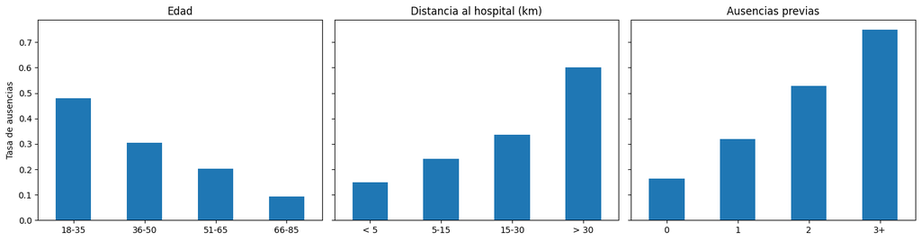

```python
fig, axes = plt.subplots(1, 3, figsize=(15, 4), sharey=True)

groups = [
    (pd.cut(df['edad'], [17, 35, 50, 65, 85], labels=['18-35', '36-50', '51-65', '66-85']), 'Edad'),
    (pd.cut(df['distancia_km'], [0, 5, 15, 30, 60], labels=['< 5', '5-15', '15-30', '> 30']), 'Distancia al hospital (km)'),
    (df['ausencias_previas'].clip(upper=3).map({0: '0', 1: '1', 2: '2', 3: '3+'}), 'Ausencias previas'),
]
for ax, (group, title) in zip(axes, groups):
    df.groupby(group, observed=True)['no_asiste'].mean().plot.bar(ax=ax, color='tab:blue')
    ax.set_title(title)
    ax.set_xlabel('')
    ax.tick_params(axis='x', rotation=0)
axes[0].set_ylabel('Tasa de ausencias')
plt.tight_layout()
plt.show()
```

Los pacientes más jóvenes, los que viven lejos y los que ya han faltado a citas anteriores se ausentan más a menudo. Ninguna variable decide por sí sola: el modelo tendrá que combinarlas.

### Paso 3: Preparar los datos

Dividimos las citas en un **conjunto de entrenamiento** (75%), del que aprende el modelo, y un **conjunto de prueba** (25%), que guardamos aparte para evaluarlo con citas que nunca ha visto. `stratify=y` mantiene la misma proporción de ausencias en los dos conjuntos.

Después **escalamos** las características: restamos la media y dividimos por la desviación típica, de modo que todas las variables se miden en "desviaciones típicas". Sin esto, una variable en km y otra en días tendrían tamaños muy distintos y el descenso del gradiente convergería despacio. La media y la desviación típica se calculan **solo con el conjunto de entrenamiento** y se aplican a los dos: el conjunto de prueba no debe influir de ninguna forma en el entrenamiento.

```python
feature_names = ['edad', 'dias_desde_ultima_cita', 'distancia_km', 'hora', 'primera_visita', 'ausencias_previas']
X = df[feature_names].to_numpy(dtype=float)
y = df['no_asiste'].to_numpy()

X_train, X_test, y_train, y_test = train_test_split(
    X, y, test_size=0.25, random_state=42, stratify=y)

# Escalado con las estadísticas del conjunto de ENTRENAMIENTO únicamente
mean = X_train.mean(axis=0)
std = X_train.std(axis=0)
X_train_s = (X_train - mean) / std
X_test_s = (X_test - mean) / std

print(f"Entrenamiento: {len(y_train)} citas ({y_train.mean():.1%} de ausencias)")
print(f"Prueba:        {len(y_test)} citas ({y_test.mean():.1%} de ausencias)")
```

```
Entrenamiento: 900 citas (26.2% de ausencias)
Prueba:        300 citas (26.3% de ausencias)
```

### Paso 4: La función sigmoide

La sigmoide $\sigma(z) = \frac{1}{1 + e^{-z}}$ convierte la puntuación lineal $z$ en una probabilidad: las puntuaciones muy positivas dan probabilidades cercanas a 1, las muy negativas dan probabilidades cercanas a 0 y $z = 0$ da exactamente 0,5, el umbral por defecto.

```
sigmoide(-4) = 0.018
sigmoide(-2) = 0.119
sigmoide( 0) = 0.500
sigmoide( 2) = 0.881
sigmoide( 4) = 0.982
```

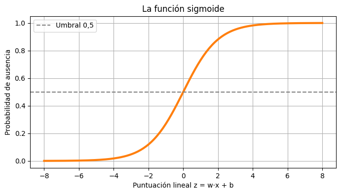

```python
def sigmoid(z):
    """Convierte cualquier número real (o array) en un valor entre 0 y 1."""
    return 1 / (1 + np.exp(-z))

for z in [-4, -2, 0, 2, 4]:
    print(f"sigmoide({z:>2}) = {sigmoid(z):.3f}")

z = np.linspace(-8, 8, 200)
plt.figure(figsize=(8, 4))
plt.plot(z, sigmoid(z), color='tab:orange', linewidth=3)
plt.axhline(0.5, color='gray', linestyle='--', label='Umbral 0,5')
plt.xlabel('Puntuación lineal z = w·x + b')
plt.ylabel('Probabilidad de ausencia')
plt.title('La función sigmoide')
plt.legend()
plt.grid(True)
plt.show()
```

### Paso 5: La función de coste: entropía cruzada (log loss)

Para medir cuánto se equivoca el modelo no podemos usar el error cuadrático medio del capítulo 2: con una sigmoide produce una superficie de coste con muchos valles. La regresión logística usa la **entropía cruzada**, o *log loss*:

$$J(w, b) = -\frac{1}{m} \sum_{i=1}^{m} \Big[ y_i \log(\hat{p}_i) + (1 - y_i) \log(1 - \hat{p}_i) \Big]$$

Para un paciente que no acudió ($y = 1$) solo cuenta el primer término, $-\log(\hat{p})$: es casi 0 si el modelo le dio una probabilidad cercana a 1 y crece sin límite cuando esa probabilidad se acerca a 0. Los errores cometidos con mucha seguridad se castigan con dureza.

```python
def compute_cost(X, y, w, b):
    """Entropía cruzada (log loss) del modelo con pesos w y sesgo b."""
    p = sigmoid(X @ w + b)
    p = np.clip(p, 1e-15, 1 - 1e-15)  # evita log(0)
    return -np.mean(y * np.log(p) + (1 - y) * np.log(1 - p))

# El coste de un único paciente que NO acudió (y = 1):
for p in [0.9, 0.5, 0.1]:
    print(f"El modelo predijo p = {p}: coste = {-np.log(p):.3f}")
```

```
El modelo predijo p = 0.9: coste = 0.105
El modelo predijo p = 0.5: coste = 0.693
El modelo predijo p = 0.1: coste = 2.303
```

### Paso 6: Entrenamiento con descenso del gradiente

Los gradientes de la entropía cruzada tienen exactamente la misma forma que en la regresión lineal; la única diferencia es que la predicción pasa ahora por la sigmoide:

$$\frac{\partial J}{\partial w} = \frac{1}{m} X^\top (\hat{p} - y) \qquad \frac{\partial J}{\partial b} = \frac{1}{m} \sum_{i=1}^{m} (\hat{p}_i - y_i)$$

y la regla de actualización es la que ya conocemos: $w := w - \alpha \frac{\partial J}{\partial w}$ y $b := b - \alpha \frac{\partial J}{\partial b}$, donde $\alpha$ es la tasa de aprendizaje. Como las características están escaladas, una tasa de aprendizaje de 0,1 converge rápido.

```
Iteración    0: coste = 0.6807
Iteración  500: coste = 0.3523
Iteración 1000: coste = 0.3511
Iteración 1500: coste = 0.3511
Iteración 2000: coste = 0.3511
Iteración 2500: coste = 0.3511

Coste final: 0.3511
Pesos aprendidos (w): [-1.269  1.169  1.02   0.365  0.286  1.026]
Sesgo aprendido (b): -1.808
```

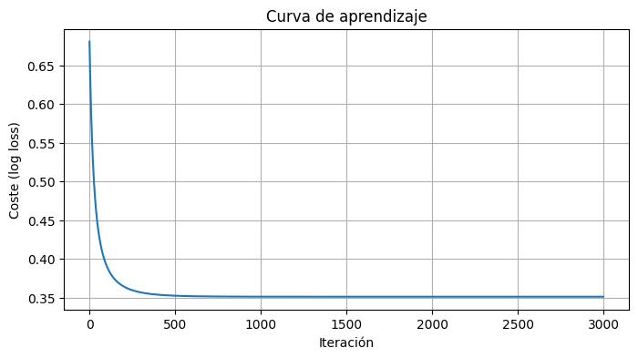

```python
def train_logistic(X, y, learning_rate=0.1, num_iterations=3000):
    """Descenso del gradiente por lotes sobre la entropía cruzada. Devuelve w, b y el coste de cada iteración."""
    m, n = X.shape
    w = np.zeros(n)
    b = 0.0
    costs = []
    for i in range(num_iterations):
        p = sigmoid(X @ w + b)          # a) predecir con los parámetros actuales
        dw = (1 / m) * X.T @ (p - y)    # b) gradientes
        db = (1 / m) * np.sum(p - y)
        w = w - learning_rate * dw      # c) un paso cuesta abajo
        b = b - learning_rate * db
        costs.append(compute_cost(X, y, w, b))
        if i % 500 == 0:
            print(f"Iteración {i:4d}: coste = {costs[-1]:.4f}")
    return w, b, costs

w, b, costs = train_logistic(X_train_s, y_train)
print(f"\nCoste final: {costs[-1]:.4f}")
print("Pesos aprendidos (w):", w)
print(f"Sesgo aprendido (b): {b:.3f}")

plt.figure(figsize=(8, 4))
plt.plot(costs)
plt.xlabel('Iteración')
plt.ylabel('Coste (log loss)')
plt.title('Curva de aprendizaje')
plt.grid(True)
plt.show()
```

El coste baja rápido y después se aplana: el modelo ha convergido.

### Paso 7: Evaluación del modelo

Con un umbral convertimos cada probabilidad en una predicción, y al comparar las predicciones con lo que realmente ocurrió hay cuatro resultados posibles, la **matriz de confusión**:

|  | Predicción: no acudirá | Predicción: acudirá |
| --- | --- | --- |
| **No acudió** | Verdadero positivo (VP) | Falso negativo (FN) |
| **Acudió** | Falso positivo (FP) | Verdadero negativo (VN) |

A partir de ella calculamos las métricas que se usan en medicina:

- **Exactitud** (*accuracy*): $\frac{VP + VN}{\text{total}}$, la proporción de predicciones correctas.
- **Sensibilidad** (*recall*): $\frac{VP}{VP + FN}$, la proporción de ausencias que el modelo detecta.
- **Especificidad**: $\frac{VN}{VN + FP}$, la proporción de asistencias que el modelo reconoce.
- **Valor predictivo positivo (VPP)**: $\frac{VP}{VP + FP}$, cuando el modelo dice "no acudirá", con qué frecuencia acierta.
- **Valor predictivo negativo (VPN)**: $\frac{VN}{VN + FN}$, cuando el modelo dice "acudirá", con qué frecuencia acierta.

Una referencia útil: un "modelo" que predice siempre que todos los pacientes acudirán ya tiene una exactitud igual a la tasa de asistencia, sin detectar ni una sola ausencia. Nuestro modelo tiene que superarlo.

```python
def predict_proba(X, w, b):
    return sigmoid(X @ w + b)

def evaluate(y_true, p, threshold=0.5):
    """Matriz de confusión y métricas clínicas para un umbral dado."""
    y_pred = (p >= threshold).astype(int)
    tp = np.sum((y_pred == 1) & (y_true == 1))
    fn = np.sum((y_pred == 0) & (y_true == 1))
    fp = np.sum((y_pred == 1) & (y_true == 0))
    tn = np.sum((y_pred == 0) & (y_true == 0))
    return {
        'umbral': threshold, 'VP': tp, 'FN': fn, 'FP': fp, 'VN': tn,
        'exactitud': (tp + tn) / len(y_true),
        'sensibilidad': tp / (tp + fn),
        'especificidad': tn / (tn + fp),
        'VPP': tp / (tp + fp),
        'VPN': tn / (tn + fn),
    }

p_test = predict_proba(X_test_s, w, b)
r = evaluate(y_test, p_test, threshold=0.5)

print("Matriz de confusión (conjunto de prueba, umbral 0,5):")
print(f"                  Predicción: no acude   Predicción: acude")
print(f"  No acudió       VP = {r['VP']:<17} FN = {r['FN']}")
print(f"  Acudió          FP = {r['FP']:<17} VN = {r['VN']}")
print()
for k in ['exactitud', 'sensibilidad', 'especificidad', 'VPP', 'VPN']:
    print(f"{k:>13}: {r[k]:.3f}")
print(f"\nReferencia (predecir siempre 'acude'): exactitud = {1 - y_test.mean():.3f}")
```

```
Matriz de confusión (conjunto de prueba, umbral 0,5):
                  Predicción: no acude   Predicción: acude
  No acudió       VP = 49                FN = 30
  Acudió          FP = 22                VN = 199

    exactitud: 0.827
 sensibilidad: 0.620
especificidad: 0.900
          VPP: 0.690
          VPN: 0.869

Referencia (predecir siempre 'acude'): exactitud = 0.737
```

El modelo supera la referencia y es muy fiable cuando dice que un paciente *sí* acudirá (VPN alto). Pero con el umbral por defecto solo detecta una parte de las ausencias (la sensibilidad): muchas faltas pasan desapercibidas.

### Paso 8: Elegir el umbral

El umbral de 0,5 es solo una convención. **Bajarlo** hace que el modelo marque a más pacientes como posibles ausencias: la sensibilidad sube (se escapan menos faltas), pero también aumentan las falsas alarmas, así que bajan la especificidad y el VPP. Qué equilibrio es mejor no es una cuestión matemática, sino clínica y organizativa: aquí una falsa alarma cuesta una llamada de recordatorio, mientras que una ausencia no detectada cuesta un hueco vacío en una lista de espera.

```python
table = pd.DataFrame([evaluate(y_test, p_test, t) for t in [0.5, 0.4, 0.3, 0.2]])
table.round(3)
```

|  | umbral | VP | FN | FP | VN | exactitud | sensibilidad | especificidad | VPP | VPN |
| --- | --- | --- | --- | --- | --- | --- | --- | --- | --- | --- |
| 0 | 0.5 | 49 | 30 | 22 | 199 | 0.827 | 0.620 | 0.900 | 0.690 | 0.869 |
| 1 | 0.4 | 54 | 25 | 32 | 189 | 0.810 | 0.684 | 0.855 | 0.628 | 0.883 |
| 2 | 0.3 | 61 | 18 | 46 | 175 | 0.787 | 0.772 | 0.792 | 0.570 | 0.907 |
| 3 | 0.2 | 68 | 11 | 64 | 157 | 0.750 | 0.861 | 0.710 | 0.515 | 0.935 |

Con un umbral de 0,3 el modelo detecta muchas más ausencias, a cambio de más llamadas de recordatorio a pacientes que habrían venido de todos modos.

### Paso 9: Interpretar los coeficientes

Como las características están escaladas, los pesos son comparables entre sí: cada uno indica cuánto cambian las log-odds (el logaritmo de la razón de probabilidades) de una ausencia cuando esa variable aumenta una desviación típica, con las demás fijas. Su exponencial, $e^{w}$, es la **razón de probabilidades** (*odds ratio*): un valor de 2 duplica la probabilidad relativa de ausencia y un valor de 0,5 la reduce a la mitad.

```
                         peso  razón de prob.
edad                   -1.269           0.281
dias_desde_ultima_cita  1.169           3.217
ausencias_previas       1.026           2.791
distancia_km            1.020           2.774
hora                    0.365           1.440
primera_visita          0.286           1.332
```

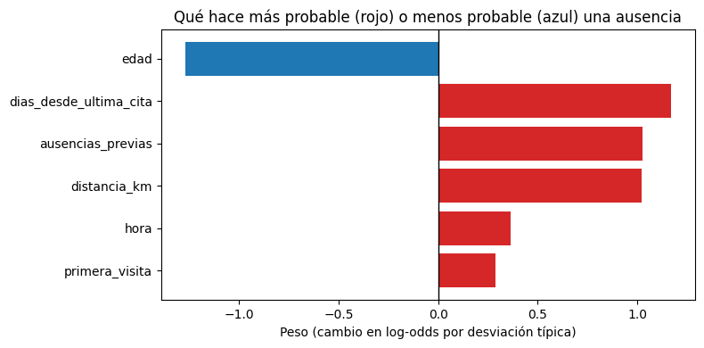

```python
coefficients = pd.DataFrame({'peso': w, 'razón de prob.': np.exp(w)}, index=feature_names)
coefficients = coefficients.reindex(coefficients['peso'].abs().sort_values(ascending=False).index)
print(coefficients.round(3))

plt.figure(figsize=(8, 4))
plt.barh(coefficients.index[::-1], coefficients['peso'][::-1],
         color=['tab:red' if v > 0 else 'tab:blue' for v in coefficients['peso'][::-1]])
plt.axvline(0, color='black', linewidth=1)
plt.xlabel('Peso (cambio en log-odds por desviación típica)')
plt.title('Qué hace más probable (rojo) o menos probable (azul) una ausencia')
plt.tight_layout()
plt.show()
```

El modelo ha encontrado el patrón que el equipo sospechaba, y en cabeza aparecen las mismas tres variables que destaca el libro. La **edad** es la señal más fuerte: cada desviación típica de edad (unos 20 años) multiplica por unas 0,28 la probabilidad relativa de ausencia, así que los pacientes mayores faltan mucho menos. Los **días desde la última cita** (×3,2), las **ausencias previas** (×2,8) y la **distancia** al hospital (×2,8) aumentan el riesgo. La hora de la cita (×1,4) y el tipo de visita (×1,3) importan menos. Son asociaciones aprendidas de los datos, no causas: le dicen al equipo a quién llamar, no por qué un paciente falta a una cita.

### Paso 10: Predecir para pacientes nuevos

```python
# edad, días desde la última cita, distancia (km), hora, primera visita, ausencias previas
new_patients = np.array([
    [35, 100, 18.0, 18, 1, 0],   # joven, mucho tiempo sin venir, vive lejos, a última hora, primera visita
    [33,  80, 14.0, 17, 1, 0],   # parecido, pero algo más cerca del perfil habitual
    [62,  30,  6.0,  9, 0, 0],   # mayor, revisión reciente, vive cerca, por la mañana
])
p_new = predict_proba((new_patients - mean) / std, w, b)

for patient, p in zip(new_patients, p_new):
    flag_05 = "marcado" if p >= 0.5 else "no marcado"
    flag_03 = "marcado" if p >= 0.3 else "no marcado"
    print(f"Paciente de {patient[0]:.0f} años: P(ausencia) = {p:5.1%} | umbral 0,5: {flag_05:<10} | umbral 0,3: {flag_03}")
```

```
Paciente de 35 años: P(ausencia) = 57.5% | umbral 0,5: marcado    | umbral 0,3: marcado
Paciente de 33 años: P(ausencia) = 36.0% | umbral 0,5: no marcado | umbral 0,3: marcado
Paciente de 62 años: P(ausencia) =  0.3% | umbral 0,5: no marcado | umbral 0,3: no marcado
```

El segundo paciente muestra por qué importa el umbral: con 0,5 el modelo no lo marcaría; con 0,3 el equipo llamaría para confirmar la cita.

### Conclusión

Hemos construido una regresión logística desde cero: la sigmoide convierte una puntuación lineal en una probabilidad, la entropía cruzada mide el error y el descenso del gradiente ajusta los pesos exactamente igual que en la regresión lineal.

También hemos visto que un clasificador no se evalúa con un solo número. La exactitud oculta que, con el umbral por defecto, muchas ausencias no se detectan; la sensibilidad, la especificidad, el VPP y el VPN cuentan la historia completa, y el umbral permite al equipo elegir el equilibrio que conviene al hospital.

En el siguiente cuaderno, *Regresión logística con scikit-learn*, entrenaremos el mismo modelo con una biblioteca y añadiremos dos herramientas de este capítulo: la **regularización**, para evitar el sobreajuste, y la **validación cruzada de k particiones**, para elegir su intensidad.